# [6기 편입 코딩 테스트]

```python
import pandas as pd # 패키지는 다 설치되어 있다고 가정
import numpy as np
import matplotlib.pyplot as plt
import seaborn as sns
import warnings
warnings.filterwarnings("ignore")
```

### [문제 1] 숫자를 입력으로 받아 해당 숫자보다 작거나 같은 모든 소수의 합를 반환하는 함수를 만드세요. [20점]

- 소수란 1과 자기 자기 자신 외의 약수를 가지지 않는 1보다 큰 자연수를 의미합니다.
- 예) 7을 입력으로 받으면 2+3+5+7인 17을 출력합니다.

  ```
    primesum(7) -> 17
  ```

```python
def primesum(n):
    sum = 0
    for i in range(1, n+1):
        a=[]
        for j in range(1, i+1):
            if i%j == 0:
                a.append(j)
        if len(a)==2:
            sum=sum+i
    return sum
```

### [문제 2] corona 데이터를 불러오고 다음의 문제를 해결하세요. [80점]

**코로나( 'corona' ) 데이터를 통해서 환자의 성별( 'sex' )를 예측하는 과정입니다.**

#### [문제 2-1] 결측치 처리 [15점]

- 다음 데이터를 불러오고 **('corona.csv')**, df 변수에 저장하세요.
- df에서 `'global_num', 'sex','infection_order','contact_number'` 열을 추출한 다음 df1에 저장해주세요.
- 각 column의 결측치를 확인하고, `'sex','global_num'`열에 결측치가 있다면 해당 행을 제거하세요.
- `'infection_order','contact_number'`의 결측치는 평균값으로 대체하세요.

```python
df=pd.read_csv('corona.csv')
df1=df[['global_num', 'sex','infection_order','contact_number']]
df1
```

|  | global_num | sex | infection_order | contact_number |
| --- | --- | --- | --- | --- |
| 0 | 2.0 | male | 1.0 | 75.0 |
| 1 | 5.0 | male | 1.0 | 31.0 |
| 2 | 6.0 | male | 2.0 | 17.0 |
| 3 | 7.0 | male | 1.0 | 9.0 |
| 4 | 9.0 | female | 2.0 | 2.0 |
| ... | ... | ... | ... | ... |
| 2238 | NaN | male | NaN | NaN |
| 2239 | 139.0 | male | NaN | 87.0 |
| 2240 | 222.0 | female | NaN | 84.0 |
| 2241 | 4345.0 | female | NaN | 21.0 |
| 2242 | 5534.0 | male | NaN | 74.0 |

2243 rows × 4 columns

```python
df1.isna().sum()
```

```
global_num          906
sex                  96
infection_order    2201
contact_number     1830
dtype: int64
```

```python
df1.dropna(subset=['sex', 'global_num'], inplace=True)
df1
```

|  | global_num | sex | infection_order | contact_number |
| --- | --- | --- | --- | --- |
| 0 | 2.0 | male | 1.0 | 75.0 |
| 1 | 5.0 | male | 1.0 | 31.0 |
| 2 | 6.0 | male | 2.0 | 17.0 |
| 3 | 7.0 | male | 1.0 | 9.0 |
| 4 | 9.0 | female | 2.0 | 2.0 |
| ... | ... | ... | ... | ... |
| 2135 | 2656.0 | female | NaN | NaN |
| 2239 | 139.0 | male | NaN | 87.0 |
| 2240 | 222.0 | female | NaN | 84.0 |
| 2241 | 4345.0 | female | NaN | 21.0 |
| 2242 | 5534.0 | male | NaN | 74.0 |

1337 rows × 4 columns

```python
df1.fillna({'infection_order':df1.infection_order.mean(), 'contact_number':df1.contact_number.mean()}, inplace=True)
df1.tail()
```

|  | global_num | sex | infection_order | contact_number |
| --- | --- | --- | --- | --- |
| 2135 | 2656.0 | female | 2.387097 | 31.710526 |
| 2239 | 139.0 | male | 2.387097 | 87.000000 |
| 2240 | 222.0 | female | 2.387097 | 84.000000 |
| 2241 | 4345.0 | female | 2.387097 | 21.000000 |
| 2242 | 5534.0 | male | 2.387097 | 74.000000 |

#### [문제 2-2] 데이터 정규화 및 변환 [15점]

- df1의 `'global_num'`열을 정규화 해주세요.
- 정규화하는 방법은 분모는 데이터의 최댓값과 최솟값의 차로 분자는 데이터에서 최솟값을 뺀 값으로 바꿔주시면 됩니다.
- df1의 `'sex'`열에서 male은 1로 female은 2로 값을 변경해주세요.

```python
min_x = df1.global_num - df1.global_num.min()

min_max = df1.global_num.max() - df1.global_num.min()
df1.global_num = min_x / min_max

# sex열 값 변환
df1["sex"] = df["sex"].apply(lambda x: 1 if x == "male" else 2)
df1.tail()
```

|  | global_num | sex | infection_order | contact_number |
| --- | --- | --- | --- | --- |
| 2135 | 0.304612 | 2 | 2.387097 | 31.710526 |
| 2239 | 0.015833 | 1 | 2.387097 | 87.000000 |
| 2240 | 0.025356 | 2 | 2.387097 | 84.000000 |
| 2241 | 0.498394 | 2 | 2.387097 | 21.000000 |
| 2242 | 0.634810 | 1 | 2.387097 | 74.000000 |

```python
sex_mapping = {"male": 1, "female":2}
df1['sex'] = df1['sex'].map(sex_mapping)
df1
```

[output not shown]

1337 rows × 4 columns

```python
from sklearn import preprocessing
min_max_scaler = preprocessing.MinMaxScaler()
fitted = min_max_scaler.fit(df1)

output = min_max_scaler.transform(df1)
output = pd.DataFrame(output, columns=df1.columns, index=list(df1.index.values))
df1['global_num'] = output['global_num']
df1
```

|  | global_num | sex | infection_order | contact_number |
| --- | --- | --- | --- | --- |
| 0 | 0.000115 | 1 | 1.000000 | 75.000000 |
| 1 | 0.000459 | 1 | 1.000000 | 31.000000 |
| 2 | 0.000574 | 1 | 2.000000 | 17.000000 |
| 3 | 0.000688 | 1 | 1.000000 | 9.000000 |
| 4 | 0.000918 | 2 | 2.000000 | 2.000000 |
| ... | ... | ... | ... | ... |
| 2135 | 0.304612 | 2 | 2.387097 | 31.710526 |
| 2239 | 0.015833 | 1 | 2.387097 | 87.000000 |
| 2240 | 0.025356 | 2 | 2.387097 | 84.000000 |
| 2241 | 0.498394 | 2 | 2.387097 | 21.000000 |
| 2242 | 0.634810 | 1 | 2.387097 | 74.000000 |

1337 rows × 4 columns

#### [문제 2-3] 데이터 시각화 [10점]

- df1에서 `'global_num','infection_order','contact_number'`열을 추출한 다음 feature에 저장해주세요
- feature들의 피어슨 상관계수를 다음과 **동일하게** 도식화 하세요. figsize는 (8,7) 입니다.

[figure not shown]

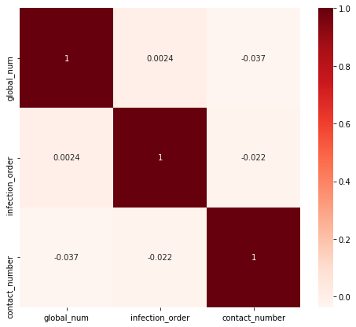

```python
feature=df1[['global_num','infection_order','contact_number']]
plt.figure(figsize=(8,7))
sns.heatmap(feature.corr(), annot=True, cmap='Reds')
plt.show()
```

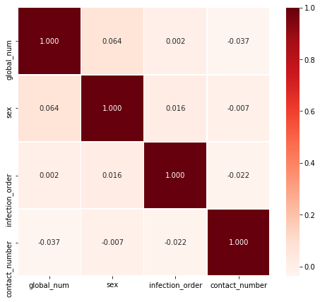

```python
corr = df1.corr(method="pearson")
plt.figure(figsize=(8,7))
sns.heatmap(data = corr, annot=True,
fmt = '.3f', linewidths=.5, cmap='Reds')
```

#### [문제 2-4] 데이터 학습 및 평가 [20점]

- X에 df1의 `'global_num','infection_order','contact_number'`열을 저장해주고 Y에 `'sex'`열을 저장해주세요.
- X, Y를 훈련 데이터와 평가 데이터로 7:3의 비율로 나눠주세요. random_state는 10으로 고정해주세요.
- RandomForest로 학습한 다음 정확도`('accuracy')`를 계산해주세요. 모델의 random_state도 10으로 고정해주세요.

  ```
    - 답안예시 -
    test set RandomForestClassifier 분류기 정확도 : 0.5572
  ```

```python
from sklearn.ensemble import RandomForestClassifier
from sklearn.metrics import accuracy_score
from sklearn.model_selection import train_test_split
from sklearn.model_selection import cross_val_score, cross_validate
```

```python
X=df1[['global_num','infection_order','contact_number']]
Y=df1['sex']

X_train, X_test, y_train, y_test=train_test_split(X,Y,test_size=0.3, random_state=10)
rf_clf = RandomForestClassifier(random_state=10)
rf_clf.fit(X_train, y_train)
test_pred = rf_clf.predict(X_test)
print("test set RandomForestClassifier 분류기 정확도 : {:.4f}".format(accuracy_score(y_test, test_pred)))
```

```
test set RandomForestClassifier 분류기 정확도 : 0.5398
```

#### [문제 2-5] 데이터 학습 및 평가(교차검증) [20점]

- **문제[2-4]** 의 모델을 교차검증을 통해 정확도를 다시 계산하는 과정입니다.
- stratified k-fold cross-validation을 사용해주세요. 5겹으로 데이터를 나누고, fold를 나누기 전 무작위로 섞도록 설정해주세요.
- random_state는 0으로 고정해주세요.
- 교차 검증별 정확도와 평균 검증 정확도를 계산해주세요.

  ```
    - 답안예시 -
    교차 검증별 정확도: [0.5448 0.5448 0.5468 0.5468 0.5281]
    평균 검증 정확도: 0.5423
  ```

```python
X = df1[['global_num', 'infection_order', 'contact_number']]
Y = df1['sex']

train_set_X, test_set_X = train_test_split(X, test_size=0.3, random_state=10)
train_set_Y, test_set_Y = train_test_split(Y, test_size=0.3, random_state=10)

rf = RandomForestClassifier(random_state=10)
rf.fit(train_set_X, train_set_Y)
pred = rf.predict(test_set_X)
accuracy = accuracy_score(test_set_Y, pred)
print(' test set RandomForestClassifier 분류기 정확도 : %.4f' %accuracy)
```

```
 test set RandomForestClassifier 분류기 정확도 : 0.5572
```

```python
from sklearn.model_selection import StratifiedKFold

skf = StratifiedKFold(n_splits=5, shuffle=True, random_state=0)
scores=cross_val_score(rf_clf, X, Y, scoring='accuracy', cv=skf)

print('교차 검증별 정확도:', np.round(scores,4))
print('평균 검증 정확도:', np.round(np.mean(scores),4))
```

```
교차 검증별 정확도: [0.5448 0.5448 0.5468 0.5468 0.5281]
평균 검증 정확도: 0.5423
```